Among the more active communities to discuss disc golf on the internet is the subreddit r/discgolf. I frequent the sub and see a lot of posts with folks asking about the “best disc” or for “disc suggestions” for their bags. This got me thinking - can we streamline this and get right down to what Reddit thinks are the best discs?

To do this, I used the package `RedditExtractoR` to pull comment data from posts to r/discgolf with search terms like “best disc”, “recommend”, or “suggest”. I then filtered down to all of their individual words and matched that against a database of disc names from alldiscs.com and the PDGA’s approved disc database.

For the R nerds, the code and walkthrough is available [here](https://discgolfdata.com/pages/code_walkthroughs/redditdiscs.html). For everyone else, here’s what I found.

## Reddit’s Top 20 most discussed discs

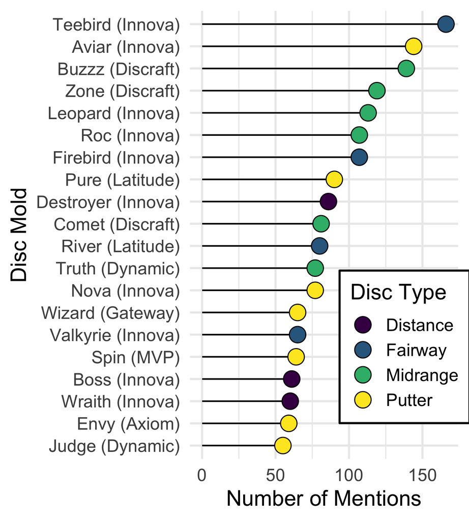

*Discs ranked by their number of mentions in recent r/discgolf comments about the “best disc” or disc “suggestions” or “recommendations”. Scroll down to see the top 10 for each disc type.*

| Manufacturer | Disc Mold | Speed | Glide | Turn | Fade |  |
| --- | --- | --- | --- | --- | --- | --- |
| Innova-Champion Discs | Teebird | 7 | 5 | 0 | 2 | [Buy It](https://amzn.to/2KIPYox) |
| Innova-Champion Discs | Aviar | 2 | 3 | 0 | 1 | [Buy It](https://amzn.to/2JGJHcs) |
| Discraft | Buzzz | 5 | 4 | -1 | 1 | [Buy It](https://amzn.to/3pJ8vQ6) |
| Discraft | Zone | 4 | 3 | 0 | 3 | [Buy It](https://amzn.to/3o5X6cJ) |
| Innova-Champion Discs | Leopard | 6 | 5 | -2 | 1 | [Buy It](https://amzn.to/3n4YIT4) |
| Innova-Champion Discs | Firebird | 9 | 3 | 0 | 4 | [Buy It](https://amzn.to/3aZYhqD) |
| Innova-Champion Discs | Roc | 4 | 4 | 0 | 3 | [Buy It](https://amzn.to/38VsDYL) |
| Latitude 64 | Pure | 3 | 3 | -1 | 1 | [Buy It](https://amzn.to/2MhC5hi) |
| Innova-Champion Discs | Destroyer | 12 | 5 | -1 | 3 | [Buy It](https://amzn.to/381KNZn) |
| Discraft | Comet | 4 | 5 | -2 | 1 | [Buy It](https://amzn.to/384wvaq) |
| Latitude 64 | River | 7 | 7 | -1 | 1 | [Buy It](https://amzn.to/3n7kkhm) |
| Innova-Champion Discs | Nova | 2 | 3 | 0 | 0 | [Buy It](https://amzn.to/2KKeBBj) |
| Dynamic Discs | Truth | 5 | 5 | -1 | 1 | Buy It |
| Innova-Champion Discs | Valkyrie | 9 | 4 | -2 | 2 | [Buy It](https://amzn.to/38WgvXz) |
| Gateway Disc Sports | Wizard | 2 | 3 | 0 | 2 | [Buy It](https://amzn.to/3aXRhue) |
| MVP Disc Sports | Spin | 2 | 4 | -2 | 0 | [Buy It](https://amzn.to/38WgGSJ) |
| Innova-Champion Discs | Boss | 13 | 5 | -1 | 3 | [Buy It](https://amzn.to/2WYhTmX) |
| Innova-Champion Discs | Wraith | 11 | 5 | -1 | 3 | [Buy It](https://amzn.to/2WYPLzR) |
| Axiom Discs | Envy | 3 | 3 | 0 | 2 | [Buy It](https://amzn.to/353hrbj) |
| Dynamic Discs | Judge | 2 | 4 | 0 | 1 | [Buy It](https://amzn.to/3rNjkm2) |

### Popular discs are popular

No great surprises here in who is highly ranked - some of the most popular discs on the market are among the most talked about! Reliable midranges like Discraft’s [Buzzz](https://amzn.to/3hJkmLD) and Innova’s [Roc](https://amzn.to/2X1RPY6) show up as some frequently suggested discs, alongside solid fairway drivers like the [TeeBird](https://amzn.to/385shzD) and [Leopard](https://amzn.to/3ohluZn) (shown here as a a midrange due to alldiscs’s ranking). The [Aviar](https://amzn.to/382Hrp0) comes up far more often than other putters. The [Zone](https://amzn.to/3o5X6cJ) shows up in 4th which seems about right given it’s a great disc (I bag two in my bag of only 15 discs!), but I wonder if it’s a little overrepresented by people just saying the word “zone”.

I found it somewhat surprising how low distance drivers were in the list. The Destroyer is the most discussed distance driver and it only shows up in 9th place. With the [Boss](https://amzn.to/2WYhTmX) and [Wraith](https://amzn.to/2WYPLzR) also in the top 20, only Innova distance drivers make the cut.

I was happy to see that my favorite putter, [Gateway’s Wizard](https://amzn.to/3hyaELL), made the top 20 That mold feels amazing in the hand and I love the feel of the SS hemp and glow plastics. This summer I bought a pack of the SS Hemp Wizards with [Grateful Dead stealie stamps](https://amzn.to/3o5MPNN). Oh yiss.

## The top 10 discs of each type

To get a little more chart action going, let’s take a look at the top 10 discs in each category.

### Reddit’s Top 10 most discussed distance drivers

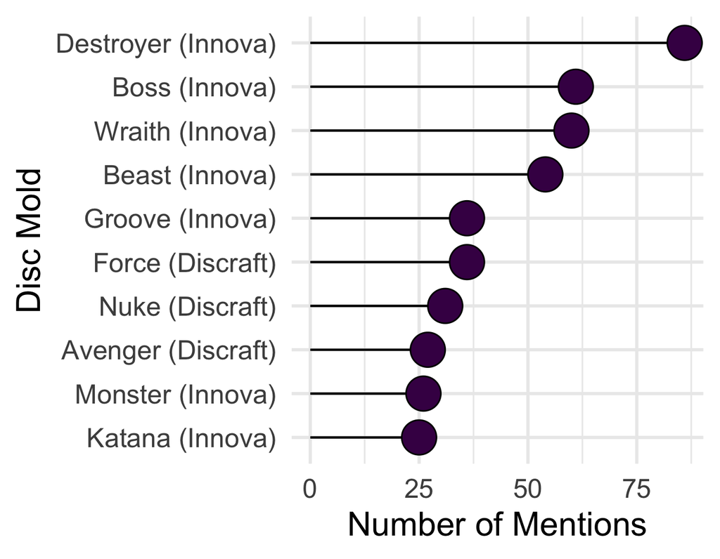

*Hmmm…are people really feelin’ the Groove that much?*

Support the project and use these links to buy your new disc!

| Manufacturer | Disc Mold | Speed | Glide | Turn | Fade |  |
| --- | --- | --- | --- | --- | --- | --- |
| Innova-Champion Discs | Destroyer | 12 | 5 | -1 | 3 | [Buy It](https://amzn.to/381KNZn) |
| Innova-Champion Discs | Boss | 13 | 5 | -1 | 3 | [Buy It](https://amzn.to/2WYhTmX) |
| Innova-Champion Discs | Wraith | 11 | 5 | -1 | 3 | [Buy It](https://amzn.to/2WYPLzR) |
| Innova-Champion Discs | Beast | 10 | 5 | -2 | 2 | [Buy It](https://amzn.to/384YAyD) |
| Discraft | Force | 12 | 5 | 0 | 3 | [Buy It](https://amzn.to/3b7kOSe) |
| Innova-Champion Discs | Groove | 13 | 6 | -2 | 2 | [Buy It](https://amzn.to/3hwkGx4) |
| Discraft | Nuke | 13 | 5 | -1 | 3 | [Buy It](https://amzn.to/3pJaBzs) |
| Discraft | Avenger | 10 | 5 | 0 | 3 | [Buy It](https://amzn.to/3rI7iuh) |
| Innova-Champion Discs | Monster | 10 | 3 | 0 | 5 | [Buy It](https://amzn.to/38Ra8o7) |
| Innova-Champion Discs | Katana | 13 | 5 | -3 | 3 | [Buy It](https://amzn.to/2KLPf62) |

### Reddit’s Top 10 most discussed fairway drivers

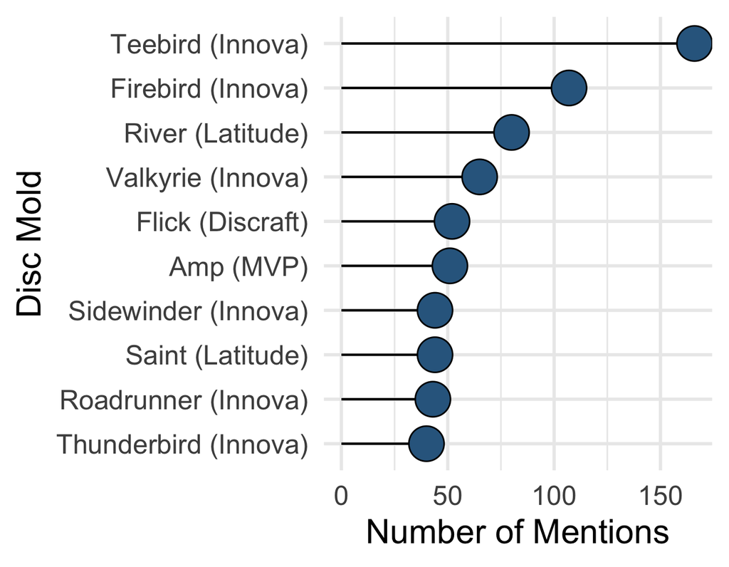

*The River might be “mentioned” a little more than reality - but it is an excellent straight flying fairway driver!*

| Manufacturer | Disc Mold | Speed | Glide | Turn | Fade |  |
| --- | --- | --- | --- | --- | --- | --- |
| Innova-Champion Discs | Teebird | 7 | 5 | 0.0 | 2 | [Buy It](https://amzn.to/2KIPYox) |
| Innova-Champion Discs | Firebird | 9 | 3 | 0.0 | 4 | [Buy It](https://amzn.to/3aZYhqD) |
| Latitude 64 | River | 7 | 7 | -1.0 | 1 | [Buy It](https://amzn.to/3n7kkhm) |
| Innova-Champion Discs | Valkyrie | 9 | 4 | -2.0 | 2 | [Buy It](https://amzn.to/38WgvXz) |
| Discraft | Flick | 9 | 4 | 1.0 | 4 | [Buy It](https://amzn.to/2JzCquM) |
| MVP Disc Sports | Amp | 8 | 5 | -1.5 | 1 | [Buy It](https://amzn.to/2JDJeYs) |
| Latitude 64 | Saint | 9 | 7 | -2.0 | 2 | [Buy It](https://amzn.to/3aXilK7) |
| Innova-Champion Discs | Sidewinder | 9 | 5 | -3.0 | 1 | [Buy It](https://amzn.to/38PbL5X) |
| Innova-Champion Discs | Roadrunner | 9 | 5 | -4.0 | 1 | [Buy It](https://amzn.to/350DZJD) |
| Innova-Champion Discs | Thunderbird | 9 | 5 | 0.0 | 2 | [Buy It](https://amzn.to/384R4DZ) |

### Reddit’s Top 10 most discussed midranges

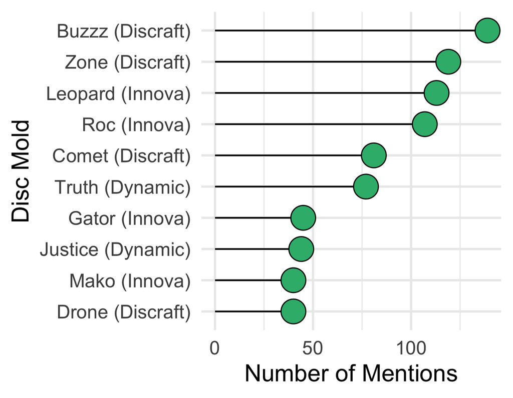

*I think you could just bag these discs and you would have a solid lineup! I love my Buzzz.*

| Manufacturer | Disc Mold | Speed | Glide | Turn | Fade |  |
| --- | --- | --- | --- | --- | --- | --- |
| Discraft | Buzzz | 5 | 4 | -1.0 | 1 | [Buy It](https://amzn.to/3pJ8vQ6) |
| Discraft | Zone | 4 | 3 | 0.0 | 3 | [Buy It](https://amzn.to/3o5X6cJ) |
| Innova-Champion Discs | Leopard | 6 | 5 | -2.0 | 1 | [Buy It](https://amzn.to/3n4YIT4) |
| Innova-Champion Discs | Roc | 4 | 4 | 0.0 | 3 | [Buy It](https://amzn.to/38VsDYL) |
| Discraft | Comet | 4 | 5 | -2.0 | 1 | [Buy It](https://amzn.to/384wvaq) |
| Dynamic Discs | Truth | 5 | 5 | -1.0 | 1 | Buy It |
| Innova-Champion Discs | Gator | 5 | 2 | 0.0 | 4 | [Buy It](https://amzn.to/3rMbiKb) |
| Dynamic Discs | Justice | 5 | 1 | 0.5 | 4 | [Buy It](https://amzn.to/3o5p1tD) |
| Discraft | Drone | 5 | 4 | 0.0 | 4 | [Buy It](https://amzn.to/3hDgKKP) |
| Innova-Champion Discs | Mako | 4 | 5 | 0.0 | 0 | [Buy It](https://amzn.to/3mZiOxW) |

### Reddit’s Top 10 most discussed putters

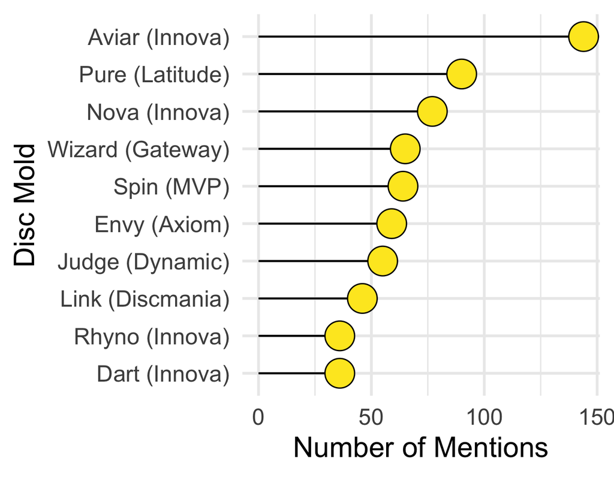

*All solid putters here. Personally I putt with Wizards and throw a Gstar Aviar for soft approaches.*

| Manufacturer | Disc Mold | Speed | Glide | Turn | Fade |  |
| --- | --- | --- | --- | --- | --- | --- |
| Innova-Champion Discs | Aviar | 2 | 3 | 0 | 1 | [Buy It](https://amzn.to/2JGJHcs) |
| Latitude 64 | Pure | 3 | 3 | -1 | 1 | [Buy It](https://amzn.to/2MhC5hi) |
| Innova-Champion Discs | Nova | 2 | 3 | 0 | 0 | [Buy It](https://amzn.to/2KKeBBj) |
| Gateway Disc Sports | Wizard | 2 | 3 | 0 | 2 | [Buy It](https://amzn.to/3aXRhue) |
| MVP Disc Sports | Spin | 2 | 4 | -2 | 0 | [Buy It](https://amzn.to/38WgGSJ) |
| Axiom Discs | Envy | 3 | 3 | 0 | 2 | [Buy It](https://amzn.to/353hrbj) |
| Dynamic Discs | Judge | 2 | 4 | 0 | 1 | [Buy It](https://amzn.to/3rNjkm2) |
| Discmania | Link | 2 | 3 | 0 | 1 | [Buy It](https://amzn.to/3rF65Ed) |
| Innova-Champion Discs | Dart | 3 | 4 | 0 | 0 | [Buy It](https://amzn.to/2X3z6Lu) |
| Innova-Champion Discs | Rhyno | 2 | 1 | 0 | 3 | [Buy It](https://amzn.to/2JBEQt1) |

### Caveats

There are a few caveats to be aware of in this exercise - namely, I matched words in comments to a list of disc names.

So words like “truth” “river” and “spin” may be used frequently and not in reference to those specific discs - but given the reliability of discs like the [Lat64 River](https://infinitediscs.com/Latitude-64-River), I feel pretty ok that the list mostly reflects reality.

If you want to explore the full data table, which contains 351 mentioned discs, head over to the code walkthrough [here](https://discgolfdata.com/pages/code_walkthroughs/redditdiscs.html).